# Yield trend & stability analyses

## Datasets: “aman” & “boro”

Two datasets (aman, boro) were analyzed. Below, you will find a quick overview for both.

### aman

```
##          Y  t.j  r.i        L           G Rep  Group    Yield
##    1: 2001 2001 1980  Barisal        BR10   1   Long 3.500000
##    2: 2001 2001 1980  Comilla        BR10   1   Long 5.011047
##    3: 2001 2001 1980  Gazipur        BR10   1   Long 4.280233
##    4: 2001 2001 1980 Rajshahi        BR10   1   Long 4.480000
##    5: 2001 2001 1980  Rangpur        BR10   1   Long 3.176419
##   ---
## 7631: 2015 2015 2014  Comilla BRRI dhan66   3 Stress 5.219160
## 7632: 2015 2015 2014  Gazipur BRRI dhan66   3 Stress 1.988598
## 7633: 2015 2015 2014 Rajshahi BRRI dhan66   3 Stress 4.926488
## 7634: 2015 2015 2014  Rangpur BRRI dhan66   3 Stress 2.200000
## 7635: 2015 2015 2014 Satkhira BRRI dhan66   3 Stress 3.820000
```

```
##       t.j            r.i           Yield
##  Min.   :2001   Min.   :1973   Min.   :0.200
##  1st Qu.:2005   1st Qu.:1988   1st Qu.:3.064
##  Median :2010   Median :1994   Median :3.914
##  Mean   :2009   Mean   :1994   Mean   :3.923
##  3rd Qu.:2013   3rd Qu.:2003   3rd Qu.:4.776
##  Max.   :2015   Max.   :2014   Max.   :8.800
```

```
## $Y
##  [1] "2001" "2002" "2003" "2004" "2005" "2006" "2007" "2008" "2009" "2010"
## [11] "2011" "2012" "2013" "2014" "2015"
##
## $L
## [1] "Barisal"  "Bhanga"   "Comilla"  "Gazipur"  "Kustia"   "Rajshahi"
## [7] "Rangpur"  "Satkhira" "Sonagazi"
##
## $G
##  [1] "BR10"        "BR11"        "BR22"        "BR23"        "BR25"
##  [6] "BR3"         "BR4"         "BR5"         "BRRI dhan30" "BRRI dhan31"
## [11] "BRRI dhan32" "BRRI dhan33" "BRRI dhan34" "BRRI dhan37" "BRRI dhan38"
## [16] "BRRI dhan39" "BRRI dhan40" "BRRI dhan41" "BRRI dhan44" "BRRI dhan46"
## [21] "BRRI dhan49" "BRRI dhan51" "BRRI dhan52" "BRRI dhan53" "BRRI dhan54"
## [26] "BRRI dhan56" "BRRI dhan57" "BRRI dhan62" "BRRI dhan66"
##
## $Rep
## [1] "1" "2" "3"
##
## $Group
## [1] "Aromatic" "Long"     "Medium"   "Short"    "Stress"
```

### boro

```
##               Y  t.j  r.i        L           G Rep Group Yield
##    1: 2001-2002 2001 1970  Barisal         BR1   1 Short  6.12
##    2: 2001-2002 2001 1970   Bhanga         BR1   1 Short  5.80
##    3: 2001-2002 2001 1970  Comilla         BR1   1 Short  6.87
##    4: 2001-2002 2001 1970 Habiganj         BR1   1 Short  5.67
##    5: 2001-2002 2001 1970 Rajshahi         BR1   1 Short  6.10
##   ---
## 8735: 2015-2016 2015 2014  Rangpur BRRI dhan69   3  Long  6.24
## 8736: 2015-2016 2015 2014 Satkhira BRRI dhan69   3  Long  7.35
## 8737: 2015-2016 2015 2014 Sonagazi BRRI dhan69   3  Long  4.84
## 8738: 2015-2016 2015 2014   Kustia BRRI dhan69   3  Long  7.14
## 8739: 2015-2016 2015 2014 Rajshahi BRRI dhan69   3  Long  6.05
```

```
##       t.j            r.i           Yield
##  Min.   :2001   Min.   :1970   Min.   :0.730
##  1st Qu.:2005   1st Qu.:1978   1st Qu.:4.700
##  Median :2010   Median :1983   Median :5.570
##  Mean   :2009   Mean   :1987   Mean   :5.462
##  3rd Qu.:2013   3rd Qu.:1994   3rd Qu.:6.370
##  Max.   :2015   Max.   :2014   Max.   :9.780
```

```
## $Y
##  [1] "2001-2002" "2002-2003" "2003-2004" "2004-2005" "2005-2006"
##  [6] "2006-2007" "2007-2008" "2008-2009" "2009-2010" "2010-2011"
## [11] "2011-2012" "2012-2013" "2013-2014" "2014-2015" "2015-2016"
##
## $L
##  [1] "Barisal"  "Bhanga"   "Comilla"  "Gazipur"  "Habiganj" "Kustia"
##  [7] "Rajshahi" "Rangpur"  "Satkhira" "Sonagazi"
##
## $G
##  [1] "BR1"         "BR12"        "BR14"        "BR15"        "BR16"
##  [6] "BR17"        "BR18"        "BR19"        "BR2"         "BR3"
## [11] "BR6"         "BR7"         "BR8"         "BR9"         "BRRI dhan28"
## [16] "BRRI dhan29" "BRRI dhan35" "BRRI dhan36" "BRRI dhan45" "BRRI dhan47"
## [21] "BRRI dhan50" "BRRI dhan55" "BRRI dhan58" "BRRI dhan59" "BRRI dhan60"
## [26] "BRRI dhan61" "BRRI dhan63" "BRRI dhan64" "BRRI dhan67" "BRRI dhan68"
## [31] "BRRI dhan69"
##
## $Rep
## [1] "1" "2" "3"
##
## $Group
## [1] "Long"   "Short"  "Stress"
```

## Obtain genotype-by-environment (GxE) means

We then analyze each environment separately in order to obtain adjusted means for the respective genotypes and Smith’s weights. Note that (i) we here denote an `Env` as a year-by-location combination and (ii) that we actually did the analysis not on the genotype `G`, but the combination of genotype and group (`Group`), i.e. `GG`:

```r
  for (sel.env in c(1:n.env)){# Loop through environments
    mod <- lm(formula = Yield ~ GG + Rep,                   # Model for RCBD
              data    = subset(dat, Env==dat$Env[sel.env])) # Data subset per Env
    m <- emmeans(mod, "GG")   # Adj. means for GG
    w <- diag(solve(vcov(m))) # Smith's weights
  }
```

We then obtain GxE means that can be plotted:

### aman

```
##                 Env  t.j  r.i                   GG adj.mean         w
##    1:  2001-Barisal 2001 1976         Aromatic-BR5 2.476667 58.926346
##    2:  2001-Barisal 2001 1997 Aromatic-BRRI dhan34 2.226667 58.926346
##    3:  2001-Barisal 2001 1998 Aromatic-BRRI dhan37 2.350000 58.926346
##    4:  2001-Barisal 2001 1998 Aromatic-BRRI dhan38 2.623333 58.926346
##    5:  2001-Barisal 2001 1980            Long-BR10 3.873333 58.926346
##   ---
## 2542: 2015-Sonagazi 2015 2010   Stress-BRRI dhan53 3.102780  7.442415
## 2543: 2015-Sonagazi 2015 2010   Stress-BRRI dhan54 3.848254  7.442415
## 2544: 2015-Sonagazi 2015 2011   Stress-BRRI dhan56 3.594197  7.442415
## 2545: 2015-Sonagazi 2015 2011   Stress-BRRI dhan57 2.372395  7.442415
## 2546: 2015-Sonagazi 2015 2014   Stress-BRRI dhan66 3.523763  7.442415
```

### boro

```
##                      Env  t.j  r.i                 GG adj.mean         w
##    1:  2001-2002-Barisal 2001 1983          Long-BR12 7.556667 16.369190
##    2:  2001-2002-Barisal 2001 1983          Long-BR14 6.390000 16.369190
##    3:  2001-2002-Barisal 2001 1983          Long-BR15 6.820000 16.369190
##    4:  2001-2002-Barisal 2001 1983          Long-BR16 7.073333 16.369190
##    5:  2001-2002-Barisal 2001 1971           Long-BR2 5.906667 16.369190
##   ---
## 2909: 2015-2016-Sonagazi 2015 1998 Stress-BRRI dhan36 4.926667  4.818834
## 2910: 2015-2016-Sonagazi 2015 2007 Stress-BRRI dhan47 5.056667  4.818834
## 2911: 2015-2016-Sonagazi 2015 2011 Stress-BRRI dhan55 6.173333  4.818834
## 2912: 2015-2016-Sonagazi 2015 2013 Stress-BRRI dhan61 4.426667  4.818834
## 2913: 2015-2016-Sonagazi 2015 2014 Stress-BRRI dhan67 3.956667  4.818834
```

### aman

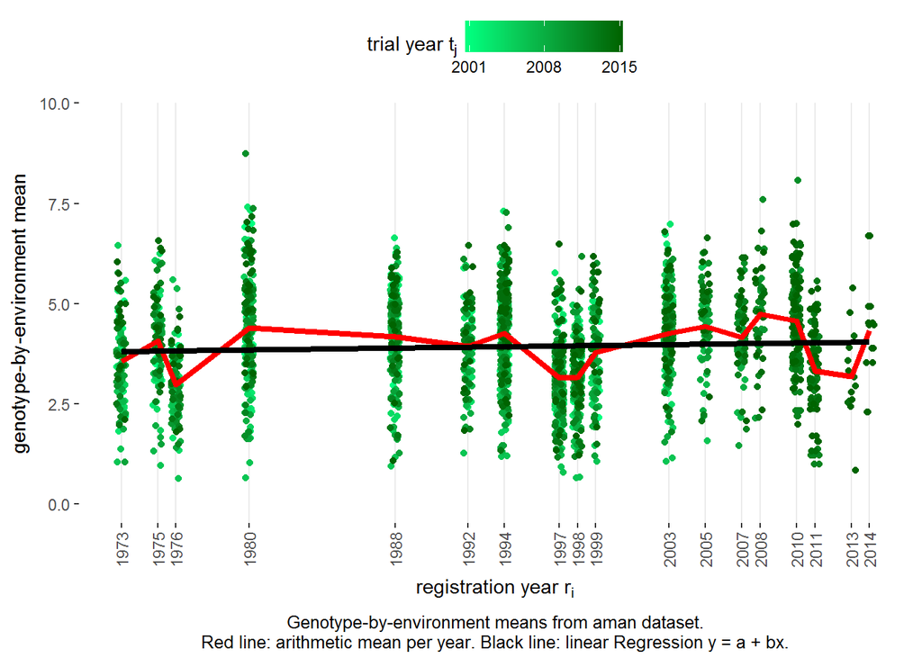

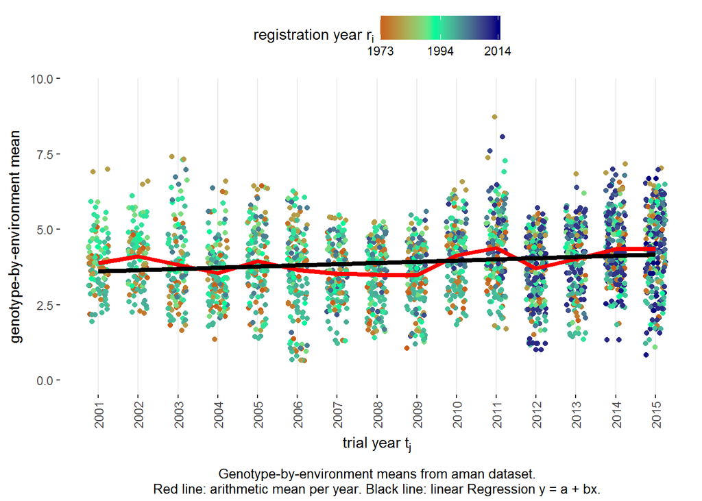

### boro

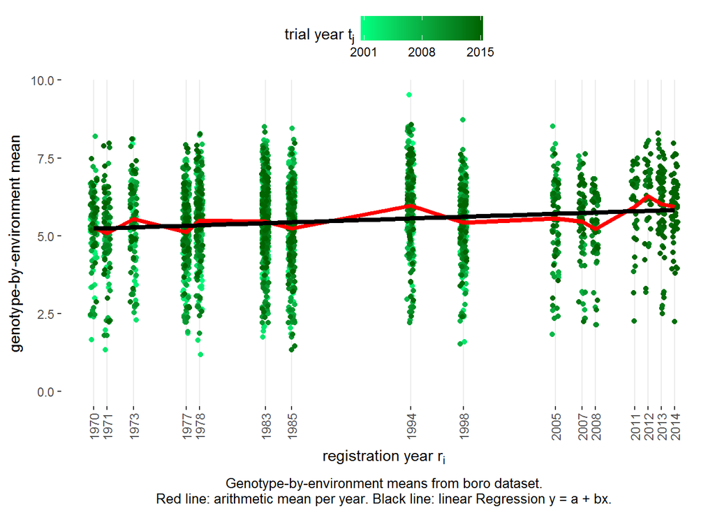

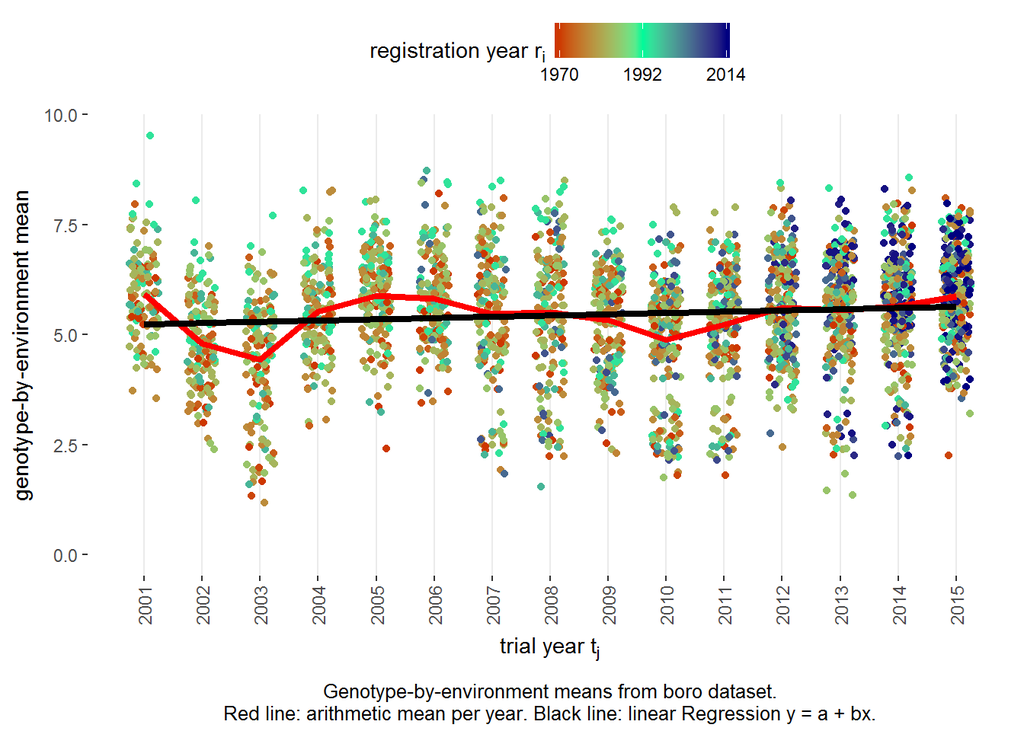

## Our models

All our models include fixed regression coefficients for the registration year $r_i$ (`ri`) and trial year $t_j$ (`tj`). Their estimates give information about the genetic and agronomic trend, respectively. In the random part of the model we have effects for genotype, year, location and their interaction effects. Note that we here write the three-way interaction `Y:L:G` as `G:Env`. Regarding their syntax, the three model denoted as “Basic”, “Shukla” and “FA” deviate only in the way we define this three-way interaction effect:

- `GG:Env` Baisc Model
- `at(GG):Env` Shukla Model
- `fa(GG):Env` FA Model

Thus, e.g. the basic model would be coded as:

```r
Basic <- asreml(fixed   = adj.mean ~ r.i + t.j,
                random  = ~ GG + L + Y + Y:L + L:GG + Y:GG + GG:Env,
                weights = w,
                family  = asreml.gaussian(dispersion=1.0),
                data    = dat,
                ran.order = "user")
```

## Estimates of regression coefficients for yield trends

Finally, we obtain estimates and tests for the genetic and agronomic trends:

### aman

[output not shown]

### boro

| Model | Trend | Absolute | SE | p.Value |
| --- | --- | --- | --- | --- |
| Basic | Genetic | 0.01158 | 0.003 | 0.0017 |
| Basic | Agronomic | 0.01854 | 0.024 | 0.4565 |
| Shukla | Genetic | 0.01157 | 0.003 | 0.0016 |
| Shukla | Agronomic | 0.01748 | 0.024 | 0.4803 |
| FA | Genetic | 0.01117 | 0.003 | 0.0032 |
| FA | Agronomic | 0.03486 | 0.022 | 0.1447 |

| Model | DF | logLik | -2logLik | AIC | BIC |
| --- | --- | --- | --- | --- | --- |
| Basic | 7 | -318.2619 | 636.5238 | 650.5238 | 691.4115 |
| Shukla | 38 | -260.5471 | 521.0942 | 597.0942 | 819.0560 |
| FA | 69 | -175.4813 | 350.9625 | 488.9625 | 891.9984 |

| Model | DF | logLik | -2logLik | AIC | BIC |
| --- | --- | --- | --- | --- | --- |
| Basic | 7 | -338.5273 | 677.0546 | 691.0546 | 732.8859 |
| Shukla | 37 | -309.4641 | 618.9283 | 692.9283 | 914.0369 |
| FA | 67 | -268.2691 | 536.5383 | 670.5383 | 1070.9241 |

## Estimates of stability variances

Furthermore, we obtain stability variances for each genotype. We can try to condense the informaion gained via both, the Shukla and FA model, by plotting the results as follows:

### aman

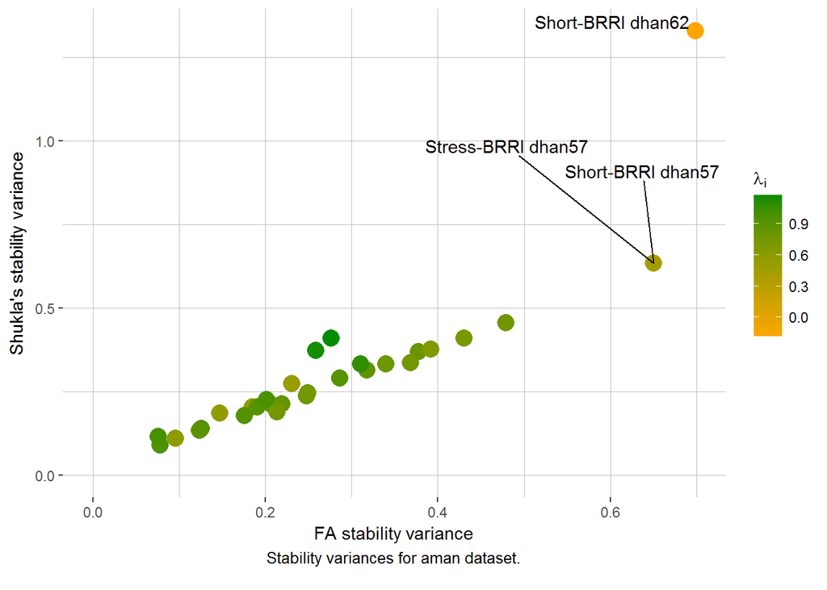

| CovParm | var.shukla | lambda | var.FA |
| --- | --- | --- | --- |
| GG | 0.2843 | NA | 0.2377 |
| L | 0.2179 | NA | 0.2709 |
| Y | 0.0377 | NA | 0.0626 |
| L:GG | 0.0494 | NA | 0.0375 |
| Y:GG | 0.0245 | NA | 0.0141 |
| R | 1.0000 | NA | 1.0000 |
| Aromatic-BR5 | 0.2740 | 0.5193 | 0.2309 |
| Aromatic-BRRI dhan34 | 0.2037 | 0.5409 | 0.1847 |
| Aromatic-BRRI dhan37 | 0.1853 | 0.5576 | 0.1470 |
| Aromatic-BRRI dhan38 | 0.1107 | 0.5967 | 0.0960 |
| Long-BR10 | 0.3738 | 1.1496 | 0.2586 |
| Long-BR22 | 0.2917 | 0.9181 | 0.2866 |
| Long-BR23 | 0.2114 | 0.8591 | 0.2071 |
| Long-BRRI dhan46 | 0.2382 | 0.8117 | 0.2474 |
| Medium-BR11 | 0.4108 | 1.1770 | 0.2764 |
| Medium-BR25 | 0.2471 | 0.7379 | 0.2494 |
| Medium-BR3 | 0.3694 | 0.8188 | 0.3777 |
| Medium-BR4 | 0.1789 | 0.9292 | 0.1755 |
| Medium-BRRI dhan30 | 0.2048 | 0.9131 | 0.1903 |
| Medium-BRRI dhan31 | 0.2270 | 0.9817 | 0.2014 |
| Medium-BRRI dhan32 | 0.3149 | 0.8570 | 0.3177 |
| Medium-BRRI dhan49 | 0.1401 | 0.9424 | 0.1256 |
| Short-BRRI dhan33 | 0.4104 | 0.7074 | 0.4306 |
| Short-BRRI dhan39 | 0.4569 | 0.7731 | 0.4787 |
| Short-BRRI dhan53 | 0.1901 | 0.7536 | 0.2138 |
| Short-BRRI dhan57 | 0.6340 | 0.4341 | 0.6502 |
| Short-BRRI dhan62 | 1.3285 | -0.1844 | 0.6986 |
| Short-BRRI dhan66 | 0.3372 | 0.7568 | 0.3685 |
| Stress-BRRI dhan40 | 0.2146 | 0.8347 | 0.2195 |
| Stress-BRRI dhan41 | 0.3333 | 0.7846 | 0.3398 |
| Stress-BRRI dhan44 | 0.1350 | 0.8920 | 0.1239 |
| Stress-BRRI dhan51 | 0.0911 | 0.9534 | 0.0776 |
| Stress-BRRI dhan52 | 0.1163 | 0.9910 | 0.0755 |
| Stress-BRRI dhan53 | 0.1901 | 0.7536 | 0.2138 |
| Stress-BRRI dhan54 | 0.3340 | 1.0812 | 0.3104 |
| Stress-BRRI dhan56 | 0.3777 | 0.6515 | 0.3916 |
| Stress-BRRI dhan57 | 0.6340 | 0.4341 | 0.6502 |
| Stress-BRRI dhan66 | 0.3372 | 0.7568 | 0.3685 |

### boro

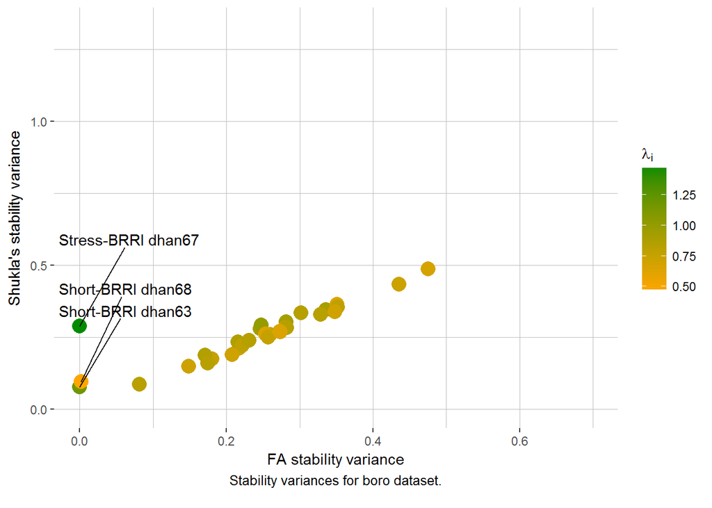

| CovParm | var.shukla | lambda | var.FA |
| --- | --- | --- | --- |
| GG | 0.0664 | NA | 0.0681 |
| L | 0.4990 | NA | 0.5065 |
| Y | 0.0872 | NA | 0.0862 |
| L:GG | 0.0648 | NA | 0.0594 |
| Y:GG | 0.0019 | NA | 0.0023 |
| R | 1.0000 | NA | 1.0000 |
| Long-BR12 | 0.2119 | 0.7306 | 0.2172 |
| Long-BR14 | 0.1760 | 0.7678 | 0.1803 |
| Long-BR15 | 0.3035 | 0.9177 | 0.2813 |
| Long-BR16 | 0.2807 | 0.9419 | 0.2458 |
| Long-BR2 | 0.2593 | 0.7861 | 0.2600 |
| Long-BR3 | 0.2342 | 0.8729 | 0.2157 |
| Long-BR7 | 0.2836 | 0.7854 | 0.2798 |
| Long-BR8 | 0.4881 | 0.6812 | 0.4750 |
| Long-BR9 | 0.1876 | 0.8569 | 0.1712 |
| Long-BRRI dhan29 | 0.2926 | 0.9999 | 0.2473 |
| Long-BRRI dhan35 | 0.2218 | 0.7981 | 0.2214 |
| Long-BRRI dhan50 | 0.1501 | 0.7184 | 0.1485 |
| Long-BRRI dhan58 | 0.3453 | 0.9058 | 0.3360 |
| Long-BRRI dhan59 | 0.3348 | 0.8403 | 0.3021 |
| Long-BRRI dhan60 | 0.2832 | 0.8360 | 0.2819 |
| Long-BRRI dhan64 | 0.1904 | 0.7135 | 0.2078 |
| Long-BRRI dhan69 | 0.1598 | 0.8269 | 0.1749 |
| Short-BR1 | 0.2697 | 0.6819 | 0.2739 |
| Short-BR6 | 0.3637 | 0.6350 | 0.3509 |
| Short-BRRI dhan28 | 0.2616 | 0.6507 | 0.2535 |
| Short-BRRI dhan45 | 0.2513 | 0.7669 | 0.2570 |
| Short-BRRI dhan63 | 0.0782 | 1.1818 | 0.0000 |
| Short-BRRI dhan68 | 0.0957 | 0.4602 | 0.0021 |
| Stress-BR17 | 0.3543 | 0.7986 | 0.3516 |
| Stress-BR18 | 0.2401 | 0.8345 | 0.2313 |
| Stress-BR19 | 0.3290 | 0.8328 | 0.3284 |
| Stress-BRRI dhan36 | 0.2704 | 0.6530 | 0.2731 |
| Stress-BRRI dhan47 | 0.3386 | 0.7051 | 0.3478 |
| Stress-BRRI dhan55 | 0.4341 | 0.7305 | 0.4357 |
| Stress-BRRI dhan61 | 0.0878 | 0.8207 | 0.0815 |
| Stress-BRRI dhan67 | 0.2895 | 1.4807 | 0.0000 |